# Assignment 2

### Bivariate Analysis - Numerical Features - Target Feature

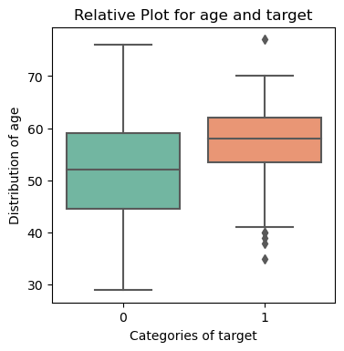

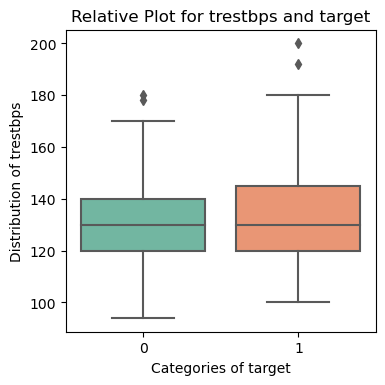

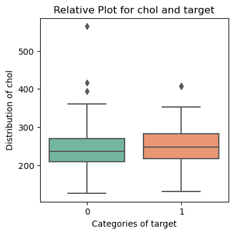

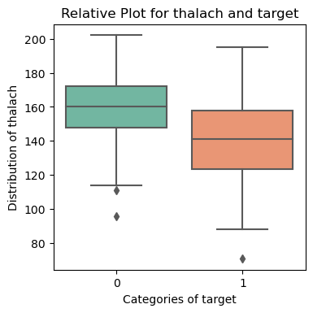

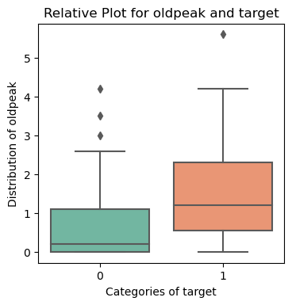

```python
for continuous_column in continuous_columns:
    continuous_to_target_plot(
        train_df,
        continuous_column,
        target_column[0],
        title=f"Relative Plot for {continuous_column} and {target_column[0]}",
        figsize=(4, 4),
        save_flag=False,
        dpi=100,
        file_path=os.path.join(result_path, f"bi-conti-target-plot-{continuous_column}.png")
    )
```

**Observations**

- **`age`** : People reporting `presence of heart dieses` has `higher median age` as compared to people reporting absence of heart dieses (~ 60 vs 52 years).
- **`age`** : There some individuals who are relatively young (age < 40) but still reports the presence of heart dieses. Even though it is a small number of sample it would be interesting to see those outliers and analyze our model around it.
- **`oldpeak`** : People reporting `presence of heart dieses` has `higher median ST depression induced by exercise relative to rest` as compared to people who are reporting absence of heart dieses.

### Correlation Analysis

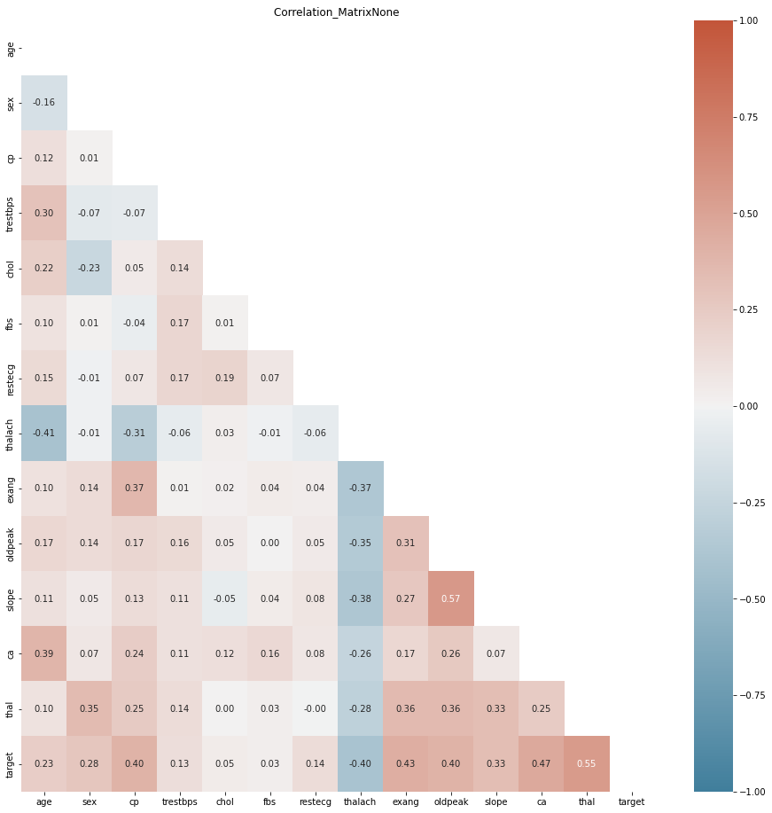

```python
corr = correlation_analysis(
    train_df,
    method='pearson',
    save_flag=False,
    plot_dir="plots",
    title=None,
    prefix="Correlation_Matrix",
    postfix=" ",
    figsize=(16, 16)
)
```

**Observations**

- There are no features which are heavily correlated with one another apart from `oldpeak` and `slope`.
- `oldpeak` and `slope` has positive correlation of 0.57 which is not that significant that we end up removing one of them. For now we assume that both the features might help the model to learn a good segmentation of our sample dataset. Later we can perform model coefficient analysis and hypothesis testing to remove features if they are not significant.
- `thal` has a higher correlation with our `target` feature. This makes `thal` one of the important features to keep in our model.

### Missing Value Treatment

```python
train_df.isnull().sum()
```

```
age         0
sex         0
cp          0
trestbps    0
chol        0
fbs         0
restecg     0
thalach     0
exang       0
oldpeak     0
slope       0
ca          3
thal        2
target      0
dtype: int64
```

```python
test_df.isnull().sum()
```

```
age         0
sex         0
cp          0
trestbps    0
chol        0
fbs         0
restecg     0
thalach     0
exang       0
oldpeak     0
slope       0
ca          1
thal        0
target      0
dtype: int64
```

As we have a very small number of missing values in the training and test dataset, it would be better to drop those rows instead of trying to figure out strategy to replace them.

```python
train_df = train_df.dropna()
test_df = test_df.dropna()
```

Let's verify that all the rows with missing values are dropped.

```python
train_df.isnull().sum()
```

```
age         0
sex         0
cp          0
trestbps    0
chol        0
fbs         0
restecg     0
thalach     0
exang       0
oldpeak     0
slope       0
ca          0
thal        0
target      0
dtype: int64
```

```python
test_df.isnull().sum()
```

```
age         0
sex         0
cp          0
trestbps    0
chol        0
fbs         0
restecg     0
thalach     0
exang       0
oldpeak     0
slope       0
ca          0
thal        0
target      0
dtype: int64
```

```python
styled_print(f"There are {train_df.shape[0]} data points for training and {test_df.shape[0]} data points for testing.")
```

```
    There are 237 data points for training and 60 data points for testing.
```

## Model Creation

We will follow these steps to create the `BASELINE` model:

- Prepare the data for modeling.
  - Create X and Y - (x_train, y_train) and (x_test, y_test)
  - Scale Continuous Features using Min-Max Scaler.
  - Scale Discrete Features using Min-Max Scaler.
- Build the `BASELINE` model on the train data.
  - Create Linear Regression Model
- Test the model on the test set.
  - Calculate $R^2$ score to measure the performance of the model.

Here `BASELINE` model means

```
- We will use all features to create the model.
```

Later we will improve the model based on the learnings from the `BASELINE` model.

### Prepare the data for modeling

```python
from sklearn.preprocessing import MinMaxScaler
```

```python
y_train = train_df[target_column[0]].copy()
x_train = train_df.drop(target_column[0], axis=1)
```

```python
y_test = test_df[target_column[0]].copy()
x_test = test_df.drop(target_column[0], axis=1)
```

```python
scaler = MinMaxScaler()
scaler.fit(x_train)
x_train = pd.DataFrame(scaler.transform(x_train),columns = x_train.columns)
x_test = pd.DataFrame(scaler.transform(x_test),columns = x_test.columns)
```

```python
x_train.head(10)
```

|  | age | sex | cp | trestbps | chol | fbs | restecg | thalach | exang | oldpeak | slope | ca | thal |
| --- | --- | --- | --- | --- | --- | --- | --- | --- | --- | --- | --- | --- | --- |
| 0 | 0.708333 | 0.0 | 1.000000 | 0.528302 | 0.641553 | 0.0 | 1.0 | 0.633588 | 0.0 | 0.714286 | 0.5 | 1.000000 | 1.0 |
| 1 | 0.395833 | 1.0 | 1.000000 | 0.339623 | 0.296804 | 1.0 | 1.0 | 0.603053 | 1.0 | 0.000000 | 0.0 | 0.666667 | 1.0 |
| 2 | 0.437500 | 1.0 | 1.000000 | 0.528302 | 0.267123 | 0.0 | 1.0 | 0.435115 | 0.0 | 0.464286 | 0.5 | 0.000000 | 1.0 |
| 3 | 0.708333 | 0.0 | 0.333333 | 0.433962 | 0.157534 | 0.0 | 0.0 | 0.824427 | 0.0 | 0.000000 | 0.0 | 0.666667 | 0.0 |
| 4 | 0.416667 | 0.0 | 0.333333 | 0.377358 | 0.331050 | 0.0 | 0.0 | 0.694656 | 0.0 | 0.000000 | 0.5 | 0.000000 | 0.0 |
| 5 | 0.583333 | 1.0 | 1.000000 | 0.547170 | 0.337900 | 0.0 | 0.0 | 0.129771 | 1.0 | 0.214286 | 0.5 | 0.333333 | 1.0 |
| 6 | 0.645833 | 0.0 | 1.000000 | 0.603774 | 0.408676 | 0.0 | 1.0 | 0.687023 | 0.0 | 0.000000 | 0.0 | 0.000000 | 0.0 |
| 7 | 0.750000 | 0.0 | 0.666667 | 0.433962 | 0.664384 | 1.0 | 1.0 | 0.656489 | 0.0 | 0.142857 | 0.0 | 0.333333 | 0.0 |
| 8 | 0.291667 | 0.0 | 0.666667 | 0.264151 | 0.198630 | 0.0 | 0.0 | 0.717557 | 0.0 | 0.035714 | 0.5 | 0.000000 | 0.0 |
| 9 | 0.666667 | 1.0 | 1.000000 | 0.415094 | 0.091324 | 0.0 | 1.0 | 0.412214 | 1.0 | 0.642857 | 0.5 | 0.333333 | 0.0 |

```python
x_test.head(10)
```

|  | age | sex | cp | trestbps | chol | fbs | restecg | thalach | exang | oldpeak | slope | ca | thal |
| --- | --- | --- | --- | --- | --- | --- | --- | --- | --- | --- | --- | --- | --- |
| 0 | 0.250000 | 0.0 | 0.666667 | 0.169811 | 0.324201 | 0.0 | 1.0 | 0.770992 | 1.0 | 0.000000 | 0.0 | 0.000000 | 0.00 |
| 1 | 0.729167 | 1.0 | 1.000000 | 0.245283 | 0.273973 | 0.0 | 1.0 | 0.190840 | 1.0 | 0.392857 | 1.0 | 0.333333 | 0.00 |
| 2 | 0.291667 | 1.0 | 1.000000 | 0.245283 | 0.116438 | 0.0 | 1.0 | 0.374046 | 1.0 | 0.446429 | 0.5 | 0.000000 | 1.00 |
| 3 | 0.125000 | 1.0 | 1.000000 | 0.301887 | 0.356164 | 0.0 | 1.0 | 0.648855 | 1.0 | 0.000000 | 0.0 | 0.000000 | 1.00 |
| 4 | 0.562500 | 1.0 | 0.333333 | 0.339623 | 0.216895 | 0.0 | 1.0 | 0.702290 | 0.0 | 0.000000 | 0.0 | 0.000000 | 1.00 |
| 5 | 0.520833 | 1.0 | 0.666667 | 0.292453 | 0.335616 | 0.0 | 1.0 | 0.618321 | 0.0 | 0.089286 | 1.0 | 0.333333 | 0.00 |
| 6 | 0.604167 | 1.0 | 1.000000 | 0.188679 | 0.438356 | 0.0 | 0.5 | 0.526718 | 0.0 | 0.785714 | 1.0 | 1.000000 | 0.75 |
| 7 | 0.708333 | 0.0 | 0.666667 | 0.386792 | 0.287671 | 0.0 | 1.0 | 0.770992 | 0.0 | 0.000000 | 0.0 | 0.000000 | 0.00 |
| 8 | 0.250000 | 0.0 | 0.333333 | 0.103774 | 0.164384 | 0.0 | 0.0 | 0.740458 | 0.0 | 0.000000 | 0.0 | 0.333333 | 0.00 |
| 9 | 0.354167 | 1.0 | 1.000000 | 0.245283 | 0.280822 | 0.0 | 1.0 | 0.557252 | 0.0 | 0.142857 | 0.0 | 0.000000 | 1.00 |

### Build the `BASELINE` model on the train data.

```python
from sklearn.linear_model import LinearRegression
```

```python
linear_regression = LinearRegression(fit_intercept=True, n_jobs=-1)
linear_regression.fit(x_train, y_train)
```

```
LinearRegression(n_jobs=-1)
```

```python
train_r2_score = linear_regression.score(x_train, y_train, sample_weight=None)
test_r2_score = linear_regression.score(x_test, y_test, sample_weight=None)
```

```python
styled_print("Performance of Baseline Linear Regression Model", header=True)
styled_print(f"The train R2 Score for Linear Regression is {train_r2_score}")
styled_print(f"The test R2 Score for Linear Regression is {test_r2_score}")
```

```
› Performance of Baseline Linear Regression Model
    The train R2 Score for Linear Regression is 0.5453825504687723
    The test R2 Score for Linear Regression is 0.4735400197312124
```

**Observations**

As indicated here, our training and test $R^2$ scores are very low. The main reason behind this is vanila linear regression models usually have poor performance for `Discreate` target variable.

For `Discrete` target variable, it is recommended to use Logistic Regression.

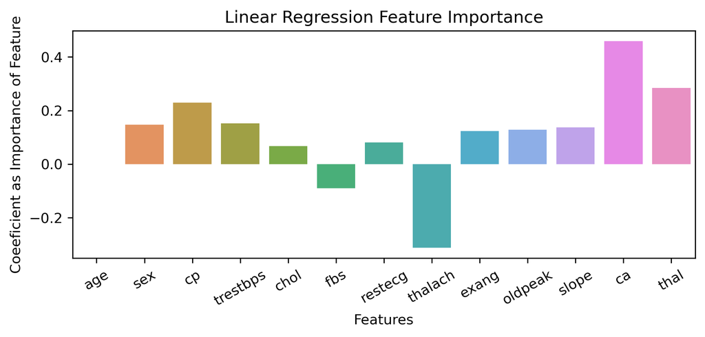

```python
feature_importance = traditional_feature_importance(linear_regression, x_train, figsize=(8, 3), title="Linear Regression Feature Importance")
```

### Improve `BASELINE` model with Ridge Regression

```python
from sklearn.linear_model import Ridge
from sklearn.model_selection import GridSearchCV
```

```python
alpha_space = list(np.logspace(-4, 0, 30))   # Checking for alpha from .0001 to 1 and finding the best value for alpha
parameters = {'alpha': alpha_space + [5, 10, 15]}
```

```python
# define the model/ estimator
ridge_regressor = Ridge()
# define the grid search
Ridge_reg= GridSearchCV(ridge_regressor, parameters, scoring='r2', cv=5, n_jobs=-1)
#fit the grid search
Ridge_reg.fit(x_train, y_train)
```

```
GridSearchCV(cv=5, estimator=Ridge(), n_jobs=-1,
             param_grid={'alpha': [0.0001, 0.00013738237958832623,
                                   0.00018873918221350977,
                                   0.0002592943797404667, 0.0003562247890262444,
                                   0.0004893900918477494, 0.0006723357536499335,
                                   0.0009236708571873865, 0.0012689610031679222,
                                   0.0017433288221999873, 0.002395026619987486,
                                   0.0032903445623126675, 0.004520353656360241,
                                   0.006210169418915616, 0.008531678524172805,
                                   0.011721022975334805, 0.01610262027560939,
                                   0.02212216291070448, 0.03039195382313198,
                                   0.041753189365604, 0.05736152510448681,
                                   0.07880462815669913, 0.1082636733874054,
                                   0.14873521072935117, 0.20433597178569418,
                                   0.2807216203941176, 0.38566204211634725,
                                   0.5298316906283708, 0.7278953843983146, 1.0, ...]},
             scoring='r2')
```

```python
# best estimator
print(Ridge_reg.best_estimator_)
```

```
Ridge(alpha=5)
```

```python
# best model
ridge_regression_model = Ridge_reg.best_estimator_
ridge_regression_model.fit(x_train, y_train)
```

```
Ridge(alpha=5)
```

```python
train_r2_score = ridge_regression_model.score(x_train, y_train, sample_weight=None)
test_r2_score = ridge_regression_model.score(x_test, y_test, sample_weight=None)
```

```python
styled_print("Performance of Baseline Ridge Regression Model", header=True)
styled_print(f"The train R2 Score for Ridge Regression is {train_r2_score}")
styled_print(f"The test R2 Score for Ridge Regression is {test_r2_score}")
```

```
› Performance of Baseline Ridge Regression Model
    The train R2 Score for Ridge Regression is 0.5403262607230834
    The test R2 Score for Ridge Regression is 0.4697211130938044
```

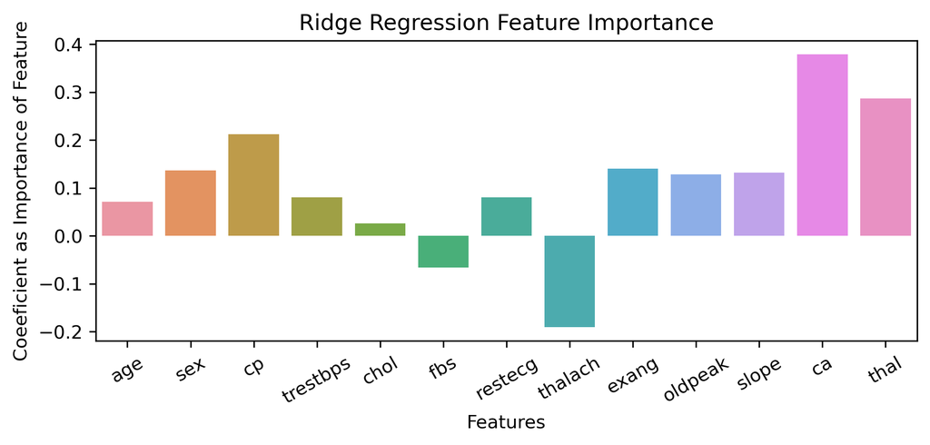

```python
feature_importance = traditional_feature_importance(ridge_regression_model, x_train, figsize=(8, 3), title="Ridge Regression Feature Importance")
```

### Improve `BASELINE` model with Lasso Regression

```python
from sklearn.linear_model import Lasso
```

```python
alpha_space = list(np.logspace(-4, 0, 30))   # Checking for alpha from .0001 to 1 and finding the best value for alpha
parameters = {'alpha': alpha_space + [5, 10, 15]}
```

```python
# define the model/ estimator
lasso_regressor = Lasso()
# define the grid search
Lasso_reg= GridSearchCV(lasso_regressor, parameters, scoring='r2', cv=5, n_jobs=-1)
#fit the grid search
Lasso_reg.fit(x_train, y_train)
```

```
GridSearchCV(cv=5, estimator=Lasso(), n_jobs=-1,
             param_grid={'alpha': [0.0001, 0.00013738237958832623,
                                   0.00018873918221350977,
                                   0.0002592943797404667, 0.0003562247890262444,
                                   0.0004893900918477494, 0.0006723357536499335,
                                   0.0009236708571873865, 0.0012689610031679222,
                                   0.0017433288221999873, 0.002395026619987486,
                                   0.0032903445623126675, 0.004520353656360241,
                                   0.006210169418915616, 0.008531678524172805,
                                   0.011721022975334805, 0.01610262027560939,
                                   0.02212216291070448, 0.03039195382313198,
                                   0.041753189365604, 0.05736152510448681,
                                   0.07880462815669913, 0.1082636733874054,
                                   0.14873521072935117, 0.20433597178569418,
                                   0.2807216203941176, 0.38566204211634725,
                                   0.5298316906283708, 0.7278953843983146, 1.0, ...]},
             scoring='r2')
```

```python
# best estimator
print(Lasso_reg.best_estimator_)
```

```
Lasso(alpha=0.006210169418915616)
```

```python
# best model
lasso_regression_model = Lasso_reg.best_estimator_
lasso_regression_model.fit(x_train, y_train)
```

```
Lasso(alpha=0.006210169418915616)
```

```python
train_r2_score = lasso_regression_model.score(x_train, y_train, sample_weight=None)
test_r2_score = lasso_regression_model.score(x_test, y_test, sample_weight=None)
```

```python
styled_print("Performance of Baseline Lasso Regression Model", header=True)
styled_print(f"The train R2 Score for Lasso Regression is {train_r2_score}")
styled_print(f"The test R2 Score for Lasso Regression is {test_r2_score}")
```

```
› Performance of Baseline Lasso Regression Model
    The train R2 Score for Lasso Regression is 0.5333242531889925
    The test R2 Score for Lasso Regression is 0.4470181314375198
```

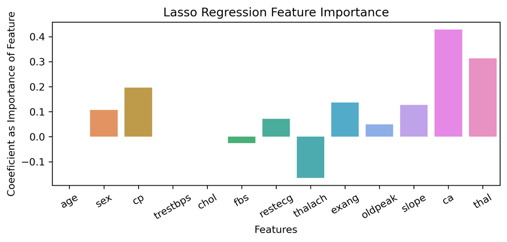

```python
feature_importance = traditional_feature_importance(lasso_regression_model, x_train, figsize=(8, 3), title="Lasso Regression Feature Importance")
```

### Improve `BASELINE` model with Removing Less Important Features

- **As Linear and Lasso Regression Showing `age` as least important feature**
- **Second least important feature is `chol`.**

We start the analysis by dropping `age` and `chol` features.

```python
x_train_updated = x_train.drop(columns=['age', 'chol'], axis=1)
x_test_updated = x_test.drop(columns=['age', 'chol'], axis=1)
```

```python
linear_regression = LinearRegression(fit_intercept=True, n_jobs=-1)
linear_regression.fit(x_train_updated, y_train)
```

```
LinearRegression(n_jobs=-1)
```

```python
train_r2_score = linear_regression.score(x_train_updated, y_train, sample_weight=None)
test_r2_score = linear_regression.score(x_test_updated, y_test, sample_weight=None)
```

```python
styled_print("Performance of Baseline Linear Regression Model", header=True)
styled_print(f"The train R2 Score for Linear Regression is {train_r2_score}")
styled_print(f"The test R2 Score for Linear Regression is {test_r2_score}")
```

```
› Performance of Baseline Linear Regression Model
    The train R2 Score for Linear Regression is 0.5451528179036751
    The test R2 Score for Linear Regression is 0.4708226296387048
```

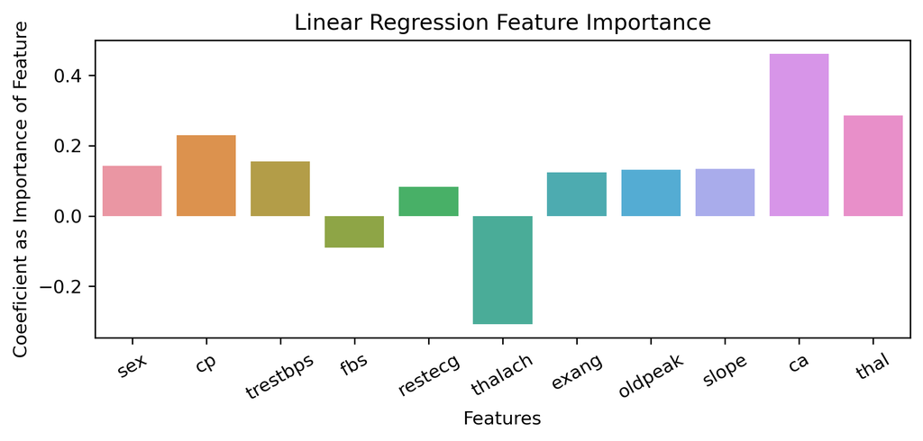

```python
feature_importance = traditional_feature_importance(linear_regression, x_train_updated, figsize=(8, 3), title="Linear Regression Feature Importance")
```

As you can see that even after dropping two features there is no improvement in the performance of the model. Our best assumption is that as over `target` variable is `discreate`, Linear, Ridge and Lasso regression wouldn't be a proper choice as algorithm. However Logistic Regression is a good choice for `discrete` target variables. In next step we briefly try Logistic Regression to prove our hypothesis. If permitted in next set of assignments, we would like to further investigate into it.

### Improve `BASELINE` model with Logistic Regression

```python
from sklearn.linear_model import LogisticRegression
```

```python
logistic_regression = LogisticRegression(penalty='l2', multi_class='ovr', fit_intercept=True, n_jobs=-1)
logistic_regression.fit(x_train, y_train)
```

```
LogisticRegression(multi_class='ovr', n_jobs=-1)
```

```python
train_mean_acc = logistic_regression.score(x_train, y_train, sample_weight=None)
test_mean_acc = logistic_regression.score(x_test, y_test, sample_weight=None)
```

```python
styled_print("Performance of Baseline Logistic Regression Model", header=True)
styled_print(f"The train Mean Accuracy for Logistic Regression is {train_mean_acc}")
styled_print(f"The test Mean Accuracy for Logistic Regression is {test_mean_acc}")
```

```
› Performance of Baseline Logistic Regression Model
    The train Mean Accuracy for Logistic Regression is 0.8438818565400844
    The test Mean Accuracy for Logistic Regression is 0.8333333333333334
```

```python
from sklearn.metrics import classification_report
target_names = ['No Heart Disease', 'Heart Disease']
```

```python
y_train_pred = logistic_regression.predict(x_train)
print(classification_report(y_train, y_train_pred, target_names=target_names))
```

```
                  precision    recall  f1-score   support

No Heart Disease       0.84      0.88      0.86       128
   Heart Disease       0.85      0.81      0.83       109

        accuracy                           0.84       237
       macro avg       0.84      0.84      0.84       237
    weighted avg       0.84      0.84      0.84       237
```

```python
y_test_pred = logistic_regression.predict(x_test)
print(classification_report(y_test, y_test_pred, target_names=target_names))
```

```
                  precision    recall  f1-score   support

No Heart Disease       0.82      0.88      0.85        32
   Heart Disease       0.85      0.79      0.81        28

        accuracy                           0.83        60
       macro avg       0.83      0.83      0.83        60
    weighted avg       0.83      0.83      0.83        60
```

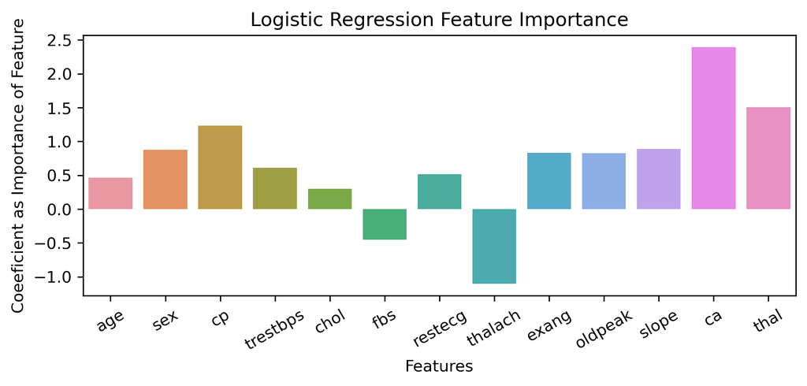

```python
feature_importance = traditional_feature_importance(logistic_regression, x_train, figsize=(8, 3), title="Logistic Regression Feature Importance")
```

Logistic Regression outputs the log odds of $Y = 1$. This means that to extract the actual coeffients we need to apply exponetial to the coefficient we got.

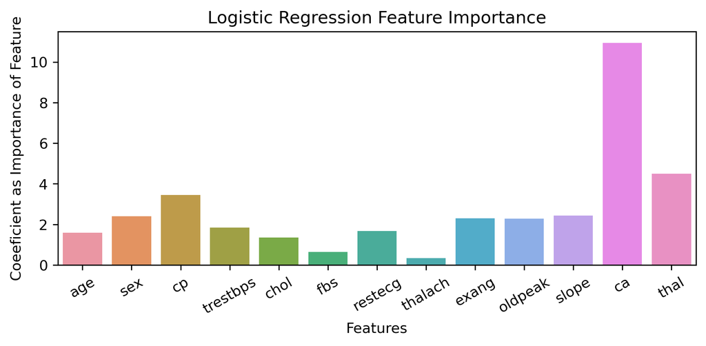

```python
feature_importance = traditional_feature_importance(logistic_regression, x_train, apply_ln=True, figsize=(8, 3), title="Logistic Regression Feature Importance")
```

We can see that the `fbs` and `thalach` are the least important features. Let's drop `thalach` feature first and test the improvement in our model.

```python
x_train_updated = x_train.drop(columns=['thalach'], axis=1)
x_test_updated = x_test.drop(columns=['thalach'], axis=1)
```

```python
logistic_regression = LogisticRegression(penalty='l2', multi_class='ovr', fit_intercept=True, n_jobs=-1)
logistic_regression.fit(x_train_updated, y_train)
```

```
LogisticRegression(multi_class='ovr', n_jobs=-1)
```

```python
train_mean_acc = logistic_regression.score(x_train_updated, y_train, sample_weight=None)
test_mean_acc = logistic_regression.score(x_test_updated, y_test, sample_weight=None)
```

```python
styled_print("Performance of Baseline Logistic Regression Model", header=True)
styled_print(f"The train Mean Accuracy for Logistic Regression is {train_mean_acc}")
styled_print(f"The test Mean Accuracy for Logistic Regression is {test_mean_acc}")
```

```
› Performance of Baseline Logistic Regression Model
    The train Mean Accuracy for Logistic Regression is 0.8438818565400844
    The test Mean Accuracy for Logistic Regression is 0.8333333333333334
```

```python
y_train_pred = logistic_regression.predict(x_train_updated)
print(classification_report(y_train, y_train_pred, target_names=target_names))
```

```
                  precision    recall  f1-score   support

No Heart Disease       0.85      0.87      0.86       128
   Heart Disease       0.84      0.82      0.83       109

        accuracy                           0.84       237
       macro avg       0.84      0.84      0.84       237
    weighted avg       0.84      0.84      0.84       237
```

```python
y_test_pred = logistic_regression.predict(x_test_updated)
print(classification_report(y_test, y_test_pred, target_names=target_names))
```

```
                  precision    recall  f1-score   support

No Heart Disease       0.81      0.91      0.85        32
   Heart Disease       0.88      0.75      0.81        28

        accuracy                           0.83        60
       macro avg       0.84      0.83      0.83        60
    weighted avg       0.84      0.83      0.83        60
```

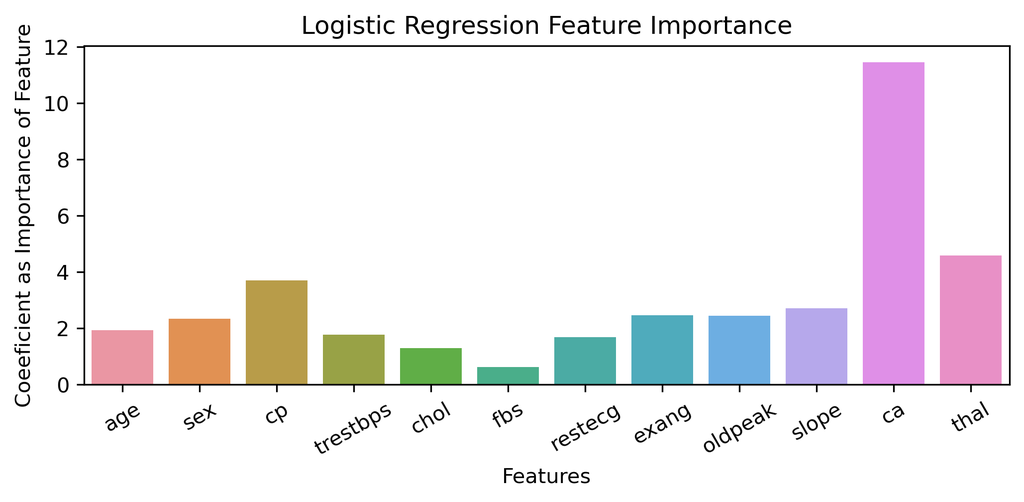

```python
feature_importance = traditional_feature_importance(logistic_regression, x_train_updated, apply_ln=True, figsize=(8, 3), title="Logistic Regression Feature Importance")
```

As we can see that even after dropping one feature we are able to get the the same model performance. This is very important as by removing not important features we can simplify our models.

```python
x_train_updated = x_train.drop(columns=['thalach', 'fbs'], axis=1)
x_test_updated = x_test.drop(columns=['thalach', 'fbs'], axis=1)
```

```python
logistic_regression = LogisticRegression(penalty='l2', multi_class='ovr', fit_intercept=True, n_jobs=-1)
logistic_regression.fit(x_train_updated, y_train)
```

```
LogisticRegression(multi_class='ovr', n_jobs=-1)
```

```python
train_mean_acc = logistic_regression.score(x_train_updated, y_train, sample_weight=None)
test_mean_acc = logistic_regression.score(x_test_updated, y_test, sample_weight=None)
```

```python
styled_print("Performance of Baseline Logistic Regression Model", header=True)
styled_print(f"The train Mean Accuracy for Logistic Regression is {train_mean_acc}")
styled_print(f"The test Mean Accuracy for Logistic Regression is {test_mean_acc}")
```

```
› Performance of Baseline Logistic Regression Model
    The train Mean Accuracy for Logistic Regression is 0.8354430379746836
    The test Mean Accuracy for Logistic Regression is 0.8166666666666667
```

```python
y_train_pred = logistic_regression.predict(x_train_updated)
print(classification_report(y_train, y_train_pred, target_names=target_names))
```

```
                  precision    recall  f1-score   support

No Heart Disease       0.84      0.86      0.85       128
   Heart Disease       0.83      0.81      0.82       109

        accuracy                           0.84       237
       macro avg       0.83      0.83      0.83       237
    weighted avg       0.84      0.84      0.84       237
```

```python
y_test_pred = logistic_regression.predict(x_test_updated)
print(classification_report(y_test, y_test_pred, target_names=target_names))
```

```
                  precision    recall  f1-score   support

No Heart Disease       0.80      0.88      0.84        32
   Heart Disease       0.84      0.75      0.79        28

        accuracy                           0.82        60
       macro avg       0.82      0.81      0.81        60
    weighted avg       0.82      0.82      0.82        60
```

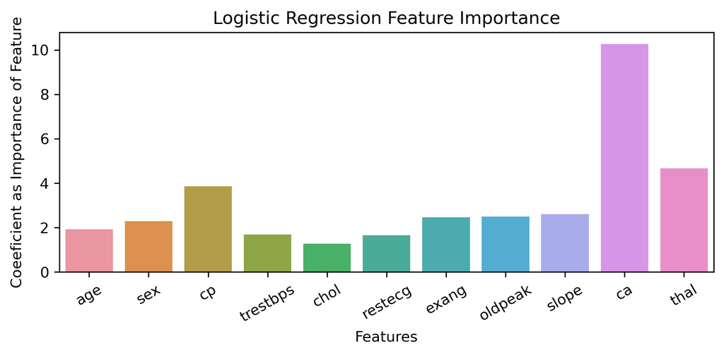

```python
feature_importance = traditional_feature_importance(logistic_regression, x_train_updated, apply_ln=True, figsize=(8, 3), title="Logistic Regression Feature Importance")
```

As we can see that after removing two features `'thalach'`, and `'fbs'`, we get decreased f1 scores for our test set. This indicates that we should only remove one of the features which is `thalach`.

## Conclusion

Vanila Linear Regression are only better when the target variable is continuous in nature. Whenever the target variable is discrete, we should use Logistic Regression model. That is also the fundamental difference between classification and regression type of problems.